## Differential Binding Analysis of ChIP-seq data

## Introduction

The ChIP-seq data used in this workflow was generated as part of a study that investigated the regulatory role of short-chain fatty acids (SCFAs) propionate and butyrate in the context of colorectal cancer (CRC). Briefly, epigenomic and transcriptomic profiles were compared in SCFA-treated and untreated CRC cells, normal cells and in mouse intestines, with the goal of gaining insight into changes in accessibility and expression of CRC-relevant genes.

The data set used in this workflow comes from propionyl lysine (Kpr) ChIP-seq on H3K18pr and H4K12pr histone marks in CRC cells. The corresponding acetyl marks are used as controls. The data identifies genomic regions marked by Kpr following treatment with sodium propionate.

Once `diffbind.sh` has been run and the resulting `.RData` object and `report.csv` file are ready to be loaded into `R`, `BiocManager`, `DiffBind`, `EnsDb.Hsapiens.v86`, `AnnotationDbi2`, `org.Hs.eg.db`, `ChIPpeakAnno`, `GenomicRanges`, packages will first have to be installed.

Once the `.RData` object has been loaded and the dependencies installed, `DiffBind` will be used for exploratory analysis and for identifying differentially bound genomic coordinates. `GenomicRanges` will then be used to convert genomic coordinates to an annotated object. `ChIPpeakAnno` will be used for annotation of differentially bound regions, and `ChIPseeker` will provide average profile and heatmap of peak binding to TSS regions and genomic feature distribution. Finally, `ReactomePA` will be used to perform pathway analysis.

## Goals

This workflow will perform the following analyses:

- Compare correlations between replicates and conditions
- Compare differential binding between histone marks
- Display fold change of normalized read counts
- Identify differentially bound regions
- Create TSS distribution profiles
- Annotate peaks and show feature distribution profiles
- Perform pathway analysis

## Setup

This R Markdown (.Rmd) file will provide a walk-through of exploratory data analysis followed by differential binding analysis, annotation and pathway analysis of histone ChIP-seq data. Each `Rmd` file has an initial `setup` chunk that applies some settings to all of the code chunks.

As in a regular R script in RStudio, a single line of code can be run with Command-Enter (Mac OS) or Ctrl-Enter (Windows). Whole chunks of code can be run with Command(/Ctrl) + Shift + Enter **or** by clicking the green “>” button in the top-right corner of the chunk. Alternatively, these options can also be implemented by selecting lines of code and choosing the desired option from the drop-down menu in the “Run” tab, in the top-right corner of the of Source section of RStudio.

To comment or uncomment a series of lines, highlight the lines and use Command(/Ctrl) + Shift + C.

The following `Bioconductor` `R` packages are required for this workflow. They can be installed using the following commands:

```r
if (!requireNamespace("BiocManager", quietly = TRUE))
    install.packages("BiocManager")
BiocManager::install("EnsDb.Hsapiens.v86")
install.packages("AnnotationDbi")
install.packages("org.Hs.eg.db")
install.packages("ChIPpeakAnno")
install.packages("GenomicRanges")

# If install.packages("packagename") command fails in newer versions of R uncomment and run the commands:
# if (!require("BiocManager", quietly = TRUE))
#    install.packages("BiocManager")
# BiocManager::install("packagename")
```

Once installed, load the required packages.

```r
library(EnsDb.Hsapiens.v86)
library(AnnotationDbi)
library(org.Hs.eg.db)
library(GenomicRanges)
library(DiffBind)
library(ChIPpeakAnno)
```

## Exploratory and Differential Binding Analysis

Before annotation and pathway analysis it good to first visualize the data and perform quality control checks. This can be done by loading the `.RData` object generated by `Diffbind` using `diffbind_chip.R` script provided in the repository.

```r
load("~/Desktop/Data/ChIP-seq/H4K12pr_ChIP.RData")
```

The `ChIP.RData` file should contain the `diff` object, which includes differential binding and contrast/covariate information. Make sure they are loaded into your global environment.

Check data frame information:

```r
# This will display experimental variables defined in the sampleSheet and differentially bound sites identified by DESeq2.
diff
```

```
## 4 Samples, 91356 sites in matrix:
##      ID     Factor Condition Treatment Replicate Caller Intervals FRiP
## 1  cnt1    control   H4K12ac     10 mM         1 counts     91356 0.06
## 2  cnt2    control   H4K12ac     10 mM         2 counts     91356 0.05
## 3 prop1 propionate   H4K12pr     10 mM         1 counts     91356 0.15
## 4 prop2 propionate   H4K12pr     10 mM         2 counts     91356 0.14
##
## 1 Contrast:
##    Group1 Members1     Group2 Members2 DB.DESeq2
## 1 control        2 propionate        2     28465
```

Next, it’s good to visualize the correlation between different replicates within each condition.

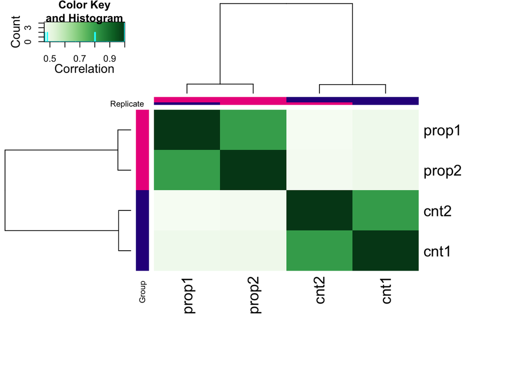

```r
# "dba" is function that is built into DiffBind package and can be used to make plots from the "diff" object.
# "Contrast" refers to the differential analysis by factor (or condition).
# In this example, the contrast is between prop (Kpr) vs cnt (Kac) histone marks defined in the sampleSheet.
# Replicates from the same condition should have a higher correlation score than those from different conditions.

dba.plotHeatmap(diff, contrast=1)
```

```r
# Alternatively, you could also run:
#plot(diff, contrast=1)
```

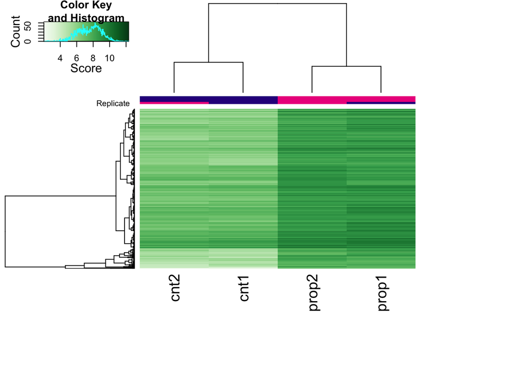

```r
# Generate a binding affinity heatmap showing affinities for differentially bound sites.
dba.plotHeatmap(diff, contrast=1, correlations=FALSE)
```

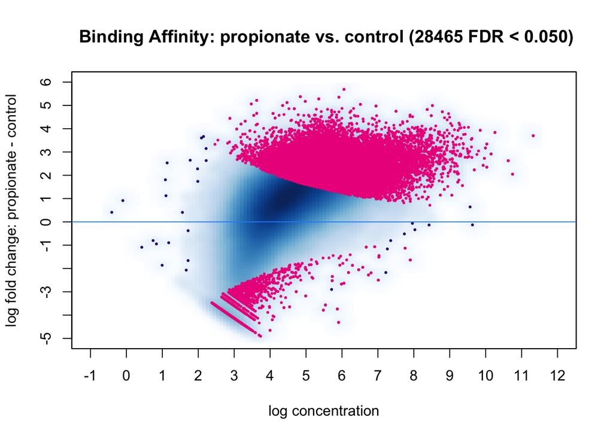

```r
# Make an MA plot showing differentially bound sites associated with the two histone marks.
dba.plotMA(diff, bFlip=TRUE)
```

```r
# Sites preferentially associated with Kpr above a significance threshold are shown as red dots in the upper panel.
```

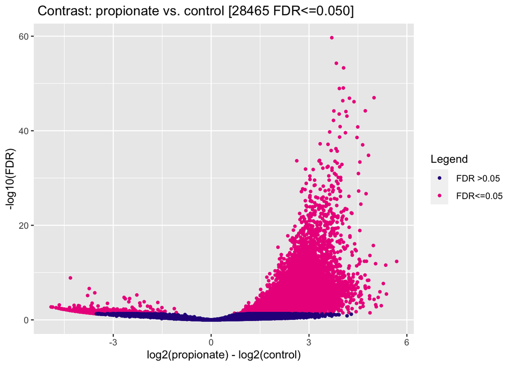

```r
# Make a volcano plot showing the log2 fold change vs -log10 FDR-adjusted (<0.05) p-value.
dba.plotVolcano(diff, bFlip=TRUE)
```

## Annotation of Differentially Bound Regions

```r
# Create an annotation data object.
annoData <- annoGR(EnsDb.Hsapiens.v86, feature="gene")
info(annoData)
```

```
## annoGR object;
## # source:  EnsDb.Hsapiens.v86
## # create at:  Sun Mar 03 00:00:00 2024 UTC
## # feature:  gene
## # Db type: EnsDb
## # Type of Gene ID: Ensembl Gene ID
## # Supporting package: ensembldb
## # Db created by: ensembldb package from Bioconductor
## # script_version: 0.3.0
## # Creation time: Thu May 18 16:32:27 2017
## # ensembl_version: 86
## # ensembl_host: localhost
## # Organism: homo_sapiens
## # taxonomy_id: 9606
## # genome_build: GRCh38
## # DBSCHEMAVERSION: 2.0
```

```r
annoData[1:2]
```

```
## annoGR object with 2 ranges and 1 metadata column:
##                   seqnames      ranges strand |   gene_name
##                      <Rle>   <IRanges>  <Rle> | <character>
##   ENSG00000223972     chr1 11869-14409      + |     DDX11L1
##   ENSG00000227232     chr1 14404-29570      - |      WASH7P
##   -------
##   seqinfo: 357 sequences from GRCh38 genome
```

First, load the `report.csv` file generated by `DiffBind` and create a new object, in this case *prop*. Make sure the data frame loaded correctly and inspect the top rows by using `head(object)`.

```r
prop <- read.csv("H4K12pr_report.csv", header=TRUE)
head(prop)
```

```
##   X seqnames     start       end width strand  Conc Conc_0mM Conc_10mM  Fold
## 1 1    chr12  52146732  52147232   501      * 11.32     8.52     12.22 -3.70
## 2 2     chr2  47033498  47033998   501      * 10.26     7.32     11.16 -3.84
## 3 3    chr14 104972892 104973392   501      *  9.52     6.38     10.44 -4.06
## 4 4    chr17  77286135  77286635   501      *  9.40     6.27     10.32 -4.05
## 5 5     chr3 139301481 139301981   501      *  9.85     6.83     10.76 -3.93
## 6 6     chr2 231605082 231605582   501      *  8.52     4.48      9.47 -4.99
##    p.value      FDR
## 1 2.26e-65 2.06e-60
## 2 1.16e-59 5.29e-55
## 3 1.64e-58 5.00e-54
## 4 3.92e-54 8.95e-50
## 5 6.24e-54 1.14e-49
## 6 6.80e-52 1.04e-47
```

Next, make a `GRanges` data frame from report table:

```r
propgr <- makeGRangesFromDataFrame(prop, keep.extra.columns=TRUE)
propgr
```

```
## GRanges object with 28465 ranges and 7 metadata columns:
##           seqnames              ranges strand |         X      Conc  Conc_0mM
##              <Rle>           <IRanges>  <Rle> | <integer> <numeric> <numeric>
##       [1]    chr12   52146732-52147232      * |         1     11.32      8.52
##       [2]     chr2   47033498-47033998      * |         2     10.26      7.32
##       [3]    chr14 104972892-104973392      * |         3      9.52      6.38
##       [4]    chr17   77286135-77286635      * |         4       9.4      6.27
##       [5]     chr3 139301481-139301981      * |         5      9.85      6.83
##       ...      ...                 ...    ... .       ...       ...       ...
##   [28461]     chr8   56319413-56319913      * |     28461      4.45      3.24
##   [28462]     chr6 160080705-160081205      * |     28462      4.61      3.22
##   [28463]     chr7   39972989-39973489      * |     28463      3.84      4.56
##   [28464]    chr13 111195174-111195674      * |     28464      5.34      4.27
##   [28465]    chr16   20979337-20979837      * |     28465       5.3      4.37
##           Conc_10mM      Fold   p.value       FDR
##           <numeric> <numeric> <numeric> <numeric>
##       [1]     12.22      -3.7  2.26e-65  2.06e-60
##       [2]     11.16     -3.84  1.16e-59  5.29e-55
##       [3]     10.44     -4.06  1.64e-58     5e-54
##       [4]     10.32     -4.05  3.92e-54  8.95e-50
##       [5]     10.76     -3.93  6.24e-54  1.14e-49
##       ...       ...       ...       ...       ...
##   [28461]       5.1     -1.86    0.0156      0.05
##   [28462]      5.31     -2.09    0.0156      0.05
##   [28463]      2.33      2.23    0.0156      0.05
##   [28464]      5.94     -1.67    0.0156      0.05
##   [28465]      5.86     -1.49    0.0156      0.05
##   -------
##   seqinfo: 23 sequences from an unspecified genome; no seqlengths
```

Annotate to within +/- 1000 bp of transcription start sites (TSS) of a transcript.

```r
prop.anno <- annotatePeakInBatch(propgr, AnnotationData=annoData, output="both", maxgap=1000L, select="all")
```

Annotate by feature.

```r
prop.anno$gene_name <- annoData$gene_name[match(prop.anno$feature, names(annoData))]
head(prop.anno$feature)
```

```
## [1] "ENSG00000257989" "ENSG00000068724" "ENSG00000233845" "ENSG00000185567"
## [5] "ENSG00000263718" "ENSG00000184640"
```

Annotate by gene symbol.

```r
prop.anno$symbol <- mapIds(org.Hs.eg.db,
                     keys=prop.anno$feature,
                     column="SYMBOL",
                     keytype="ENSEMBL",
                     multiVals="first")
prop.anno
```

```
## GRanges object with 45643 ranges and 18 metadata columns:
##                          seqnames              ranges strand |         X
##                             <Rle>           <IRanges>  <Rle> | <integer>
##   X00001.ENSG00000257989    chr12   52146732-52147232      * |         1
##   X00002.ENSG00000068724     chr2   47033498-47033998      * |         2
##   X00002.ENSG00000233845     chr2   47033498-47033998      * |         2
##   X00003.ENSG00000185567    chr14 104972892-104973392      * |         3
##   X00004.ENSG00000263718    chr17   77286135-77286635      * |         4
##                      ...      ...                 ...    ... .       ...
##   X28463.ENSG00000065883     chr7   39972989-39973489      * |     28463
##   X28464.ENSG00000102606    chr13 111195174-111195674      * |     28464
##   X28464.ENSG00000274614    chr13 111195174-111195674      * |     28464
##   X28465.ENSG00000188215    chr16   20979337-20979837      * |     28465
##   X28465.ENSG00000158486    chr16   20979337-20979837      * |     28465
##                               Conc  Conc_0mM Conc_10mM      Fold   p.value
##                          <numeric> <numeric> <numeric> <numeric> <numeric>
##   X00001.ENSG00000257989     11.32      8.52     12.22      -3.7  2.26e-65
##   X00002.ENSG00000068724     10.26      7.32     11.16     -3.84  1.16e-59
##   X00002.ENSG00000233845     10.26      7.32     11.16     -3.84  1.16e-59
##   X00003.ENSG00000185567      9.52      6.38     10.44     -4.06  1.64e-58
##   X00004.ENSG00000263718       9.4      6.27     10.32     -4.05  3.92e-54
##                      ...       ...       ...       ...       ...       ...
##   X28463.ENSG00000065883      3.84      4.56      2.33      2.23    0.0156
##   X28464.ENSG00000102606      5.34      4.27      5.94     -1.67    0.0156
##   X28464.ENSG00000274614      5.34      4.27      5.94     -1.67    0.0156
##   X28465.ENSG00000188215       5.3      4.37      5.86     -1.49    0.0156
##   X28465.ENSG00000158486       5.3      4.37      5.86     -1.49    0.0156
##                                FDR        peak         feature start_position
##                          <numeric> <character>     <character>      <integer>
##   X00001.ENSG00000257989  2.06e-60       00001 ENSG00000257989       52092485
##   X00002.ENSG00000068724  5.29e-55       00002 ENSG00000068724       46916157
##   X00002.ENSG00000233845  5.29e-55       00002 ENSG00000233845       47035279
##   X00003.ENSG00000185567     5e-54       00003 ENSG00000185567      104937244
##   X00004.ENSG00000263718  8.95e-50       00004 ENSG00000263718       77257737
##                      ...       ...         ...             ...            ...
##   X28463.ENSG00000065883      0.05       28463 ENSG00000065883       39950037
##   X28464.ENSG00000102606      0.05       28464 ENSG00000102606      111114559
##   X28464.ENSG00000274614      0.05       28464 ENSG00000274614      111182111
##   X28465.ENSG00000188215      0.05       28465 ENSG00000188215       20854925
##   X28465.ENSG00000158486      0.05       28465 ENSG00000158486       20933111
```

[output cut: 26 more lines]

```
##                          fromOverlappingOrNearest    gene_name      symbol
##                                       <character>  <character> <character>
##   X00001.ENSG00000257989          NearestLocation  RP1-288H2.2        <NA>
##   X00002.ENSG00000068724              Overlapping        TTC7A       TTC7A
##   X00002.ENSG00000233845          NearestLocation   AC093732.1        <NA>
##   X00003.ENSG00000185567          NearestLocation       AHNAK2      AHNAK2
##   X00004.ENSG00000263718          NearestLocation RP11-285E9.6  SEPTIN9-DT
##                      ...                      ...          ...         ...
##   X28463.ENSG00000065883          NearestLocation        CDK13       CDK13
##   X28464.ENSG00000102606              Overlapping      ARHGEF7     ARHGEF7
##   X28464.ENSG00000274614          NearestLocation  RP11-17E4.1        <NA>
##   X28465.ENSG00000188215          NearestLocation      DCUN1D3     DCUN1D3
##   X28465.ENSG00000158486              Overlapping        DNAH3       DNAH3
##   -------
##   seqinfo: 23 sequences from an unspecified genome; no seqlengths
```

Annotate by gene entrezID.

```r
prop.anno$entrezID <- mapIds(org.Hs.eg.db,
                     keys=prop.anno$feature,
                     column="ENTREZID",
                     keytype="ENSEMBL",
                     multiVals="first")
prop.anno
```

```
## GRanges object with 45643 ranges and 19 metadata columns:
##                          seqnames              ranges strand |         X
##                             <Rle>           <IRanges>  <Rle> | <integer>
##   X00001.ENSG00000257989    chr12   52146732-52147232      * |         1
##   X00002.ENSG00000068724     chr2   47033498-47033998      * |         2
##   X00002.ENSG00000233845     chr2   47033498-47033998      * |         2
##   X00003.ENSG00000185567    chr14 104972892-104973392      * |         3
##   X00004.ENSG00000263718    chr17   77286135-77286635      * |         4
##                      ...      ...                 ...    ... .       ...
##   X28463.ENSG00000065883     chr7   39972989-39973489      * |     28463
##   X28464.ENSG00000102606    chr13 111195174-111195674      * |     28464
##   X28464.ENSG00000274614    chr13 111195174-111195674      * |     28464
##   X28465.ENSG00000188215    chr16   20979337-20979837      * |     28465
##   X28465.ENSG00000158486    chr16   20979337-20979837      * |     28465
##                               Conc  Conc_0mM Conc_10mM      Fold   p.value
##                          <numeric> <numeric> <numeric> <numeric> <numeric>
##   X00001.ENSG00000257989     11.32      8.52     12.22      -3.7  2.26e-65
##   X00002.ENSG00000068724     10.26      7.32     11.16     -3.84  1.16e-59
##   X00002.ENSG00000233845     10.26      7.32     11.16     -3.84  1.16e-59
##   X00003.ENSG00000185567      9.52      6.38     10.44     -4.06  1.64e-58
##   X00004.ENSG00000263718       9.4      6.27     10.32     -4.05  3.92e-54
##                      ...       ...       ...       ...       ...       ...
##   X28463.ENSG00000065883      3.84      4.56      2.33      2.23    0.0156
##   X28464.ENSG00000102606      5.34      4.27      5.94     -1.67    0.0156
##   X28464.ENSG00000274614      5.34      4.27      5.94     -1.67    0.0156
##   X28465.ENSG00000188215       5.3      4.37      5.86     -1.49    0.0156
##   X28465.ENSG00000158486       5.3      4.37      5.86     -1.49    0.0156
##                                FDR        peak         feature start_position
##                          <numeric> <character>     <character>      <integer>
##   X00001.ENSG00000257989  2.06e-60       00001 ENSG00000257989       52092485
##   X00002.ENSG00000068724  5.29e-55       00002 ENSG00000068724       46916157
##   X00002.ENSG00000233845  5.29e-55       00002 ENSG00000233845       47035279
##   X00003.ENSG00000185567     5e-54       00003 ENSG00000185567      104937244
##   X00004.ENSG00000263718  8.95e-50       00004 ENSG00000263718       77257737
##                      ...       ...         ...             ...            ...
##   X28463.ENSG00000065883      0.05       28463 ENSG00000065883       39950037
##   X28464.ENSG00000102606      0.05       28464 ENSG00000102606      111114559
##   X28464.ENSG00000274614      0.05       28464 ENSG00000274614      111182111
##   X28465.ENSG00000188215      0.05       28465 ENSG00000188215       20854925
##   X28465.ENSG00000158486      0.05       28465 ENSG00000158486       20933111
```

[output cut: 39 more lines]

```
##                             entrezID
##                          <character>
##   X00001.ENSG00000257989        <NA>
##   X00002.ENSG00000068724       57217
##   X00002.ENSG00000233845        <NA>
##   X00003.ENSG00000185567      113146
##   X00004.ENSG00000263718   105371907
##                      ...         ...
##   X28463.ENSG00000065883        8621
##   X28464.ENSG00000102606        8874
##   X28464.ENSG00000274614        <NA>
##   X28465.ENSG00000188215      123879
##   X28465.ENSG00000158486       55567
##   -------
##   seqinfo: 23 sequences from an unspecified genome; no seqlengths
```

Next, make a report of the annotated output.

```r
# write annotated output
diffprop <- data.frame(seqnames=seqnames(prop.anno),
  starts=(start(prop.anno)-1),
  ends=end(prop.anno),
  ENSG=prop.anno$feature,
  ENSG.strand=prop.anno$feature_strand,
  insideFeature=prop.anno$insideFeature,
  distancetoFeature=prop.anno$distancetoFeature,
  shortestDistance=prop.anno$shortestDistance,
  symbol=prop.anno$symbol,
  entrezID=prop.anno$entrezID,
  fold=prop.anno$Fold,
  conc=prop.anno$Conc,
  conc_0mM=prop.anno$Conc_0mM,
  conc_10mM=prop.anno$Conc_10mM,
  FDR=prop.anno$FDR)
head(diffprop)
```

```
##   seqnames    starts      ends            ENSG ENSG.strand insideFeature
## 1    chr12  52146731  52147232 ENSG00000257989           -      upstream
## 2     chr2  47033497  47033998 ENSG00000068724           +        inside
## 3     chr2  47033497  47033998 ENSG00000233845           -    downstream
## 4    chr14 104972891 104973392 ENSG00000185567           -        inside
## 5    chr17  77286134  77286635 ENSG00000263718           -      upstream
## 6    chr17  77286134  77286635 ENSG00000184640           +        inside
##   distancetoFeature shortestDistance     symbol  entrezID  fold  conc conc_0mM
## 1            -42435            42435       <NA>      <NA> -3.70 11.32     8.52
## 2            117341            42139      TTC7A     57217 -3.84 10.26     7.32
## 3              7026             1281       <NA>      <NA> -3.84 10.26     7.32
## 4              5465             4965     AHNAK2    113146 -4.06  9.52     6.38
## 5             -4238             4238 SEPTIN9-DT 105371907 -4.05  9.40     6.27
## 6              5566             5566    SEPTIN9     10801 -4.05  9.40     6.27
##   conc_10mM      FDR
## 1     12.22 2.06e-60
## 2     11.16 5.29e-55
## 3     11.16 5.29e-55
## 4     10.44 5.00e-54
## 5     10.32 8.95e-50
## 6     10.32 8.95e-50
```

Save the annotated output data table.

```r
write.table(diffprop, file="prop.anno.bed", quote=FALSE, sep="\t", row.names=FALSE, col.names=TRUE)
dim(diffprop)
```

```
## [1] 45643    15
```

**NOTE:** The final output contains a table with features showing positive and negative fold change. In this example, the positive vs negative fold change relationship is reversed, with Kpr associated genes labeled as negative fold change. You may wish to select only Kpr bound regions by opening the `.report.csv` or `.anno.bed` files in MS Excel, selecting the “fold” column, clicking on “Sort & Filter” and selecting only “Greater Than” or “Less Than” “0” entries.

## Profile of Differential Binding to TSS Regions

The next several modules will require `ChIPseeker` and `TxDb.Hsapiens.UCSC.hg38.knownGene` packages.

```r
# Install `ChIPseeker` package:
#if (!requireNamespace("BiocManager", quietly = TRUE))
#    install.packages("BiocManager")
#BiocManager::install("ChIPseeker")
```

```r
# Install `TxDb.Hsapiens.UCSC.hg38.knownGene` package:
#if (!requireNamespace("BiocManager", quietly = TRUE))
#    install.packages("BiocManager")
#BiocManager::install("TxDb.Hsapiens.UCSC.hg38.knownGene")
```

Load the required packages:

```r
library(ChIPseeker)
library(TxDb.Hsapiens.UCSC.hg38.knownGene)
```

Create a *TxDb* object based on the UCSC hg38 assembly of the human genome.

```r
txdb <- TxDb.Hsapiens.UCSC.hg38.knownGene
```

Annotate peaks to 3000 bp upstream and downstream of promoters and generate heatmap.

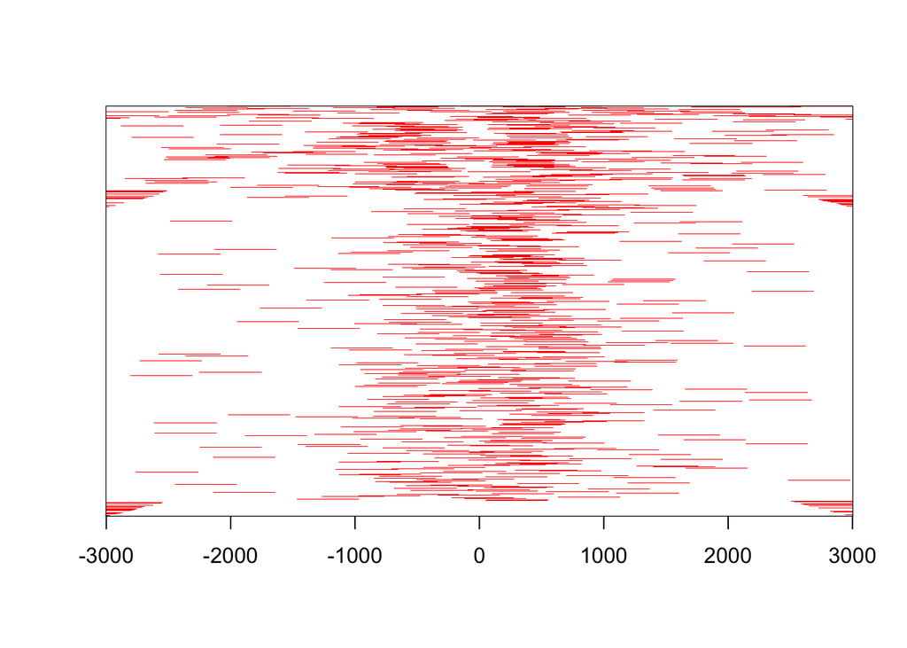

```r
promoter <- getPromoters(TxDb=txdb, upstream=3000, downstream=3000)
tagMatrix <- getTagMatrix(propgr, windows=promoter)
tagHeatmap(tagMatrix, xlim=c(-3000, 3000), color="red")
```

Plot peak distributions profile 3000 bp upstream and downstream of TSS.

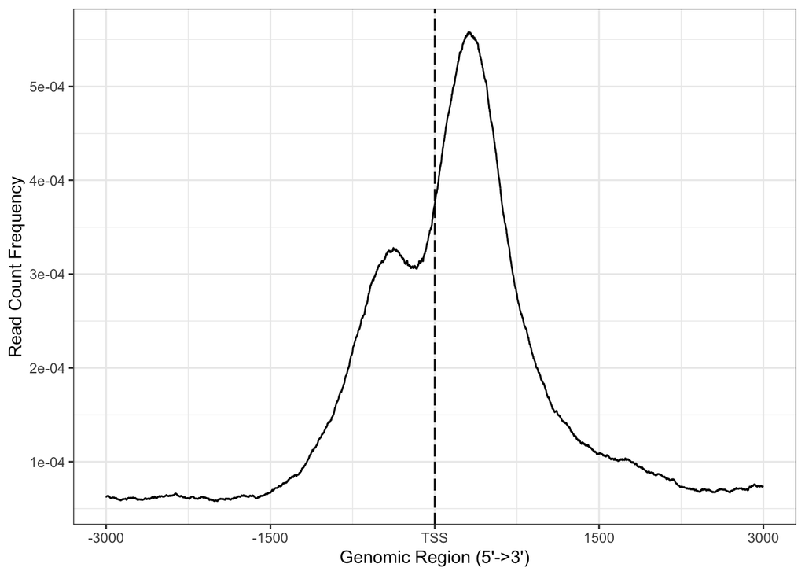

```r
plotAvgProf(tagMatrix, xlim=c(-3000, 3000), xlab="Genomic Region (5'->3')", ylab = "Read Count Frequency")
```

Resample peak distribution profile 1000 times by running bootstrapping with 0.95 confidence cutoff.

```
## >> Running bootstrapping for tag matrix...        2024-03-03 21:59:59
```

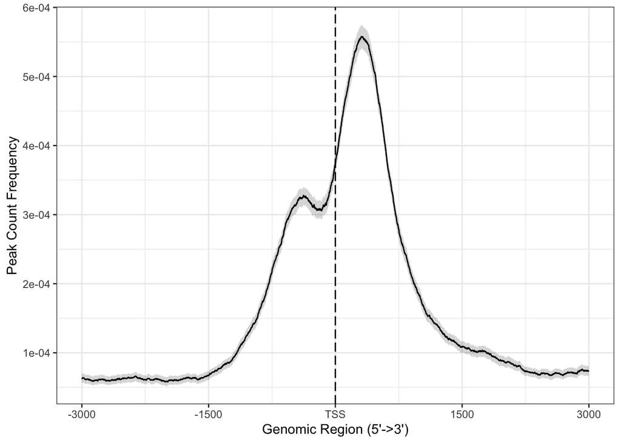

```r
plotAvgProf(tagMatrix, xlim=c(-3000, 3000), conf = 0.95, resample = 1000)
```

Annotate again to 3000 bp upstream and downstream of TSS by using `org.Hs.eg.db`.

```r
peakAnno <- annotatePeak(propgr, tssRegion=c(-3000, 3000), TxDb=txdb, annoDb="org.Hs.eg.db")
```

```
## >> preparing features information...      2024-03-03 22:00:05
## >> identifying nearest features...        2024-03-03 22:00:07
## >> calculating distance from peak to TSS...   2024-03-03 22:00:08
## >> assigning genomic annotation...        2024-03-03 22:00:08
## >> adding gene annotation...          2024-03-03 22:00:46
```

```
## >> assigning chromosome lengths           2024-03-03 22:00:47
## >> done...                    2024-03-03 22:00:47
```

Plot differentially bound feature distribution as a pie or a bar plot.

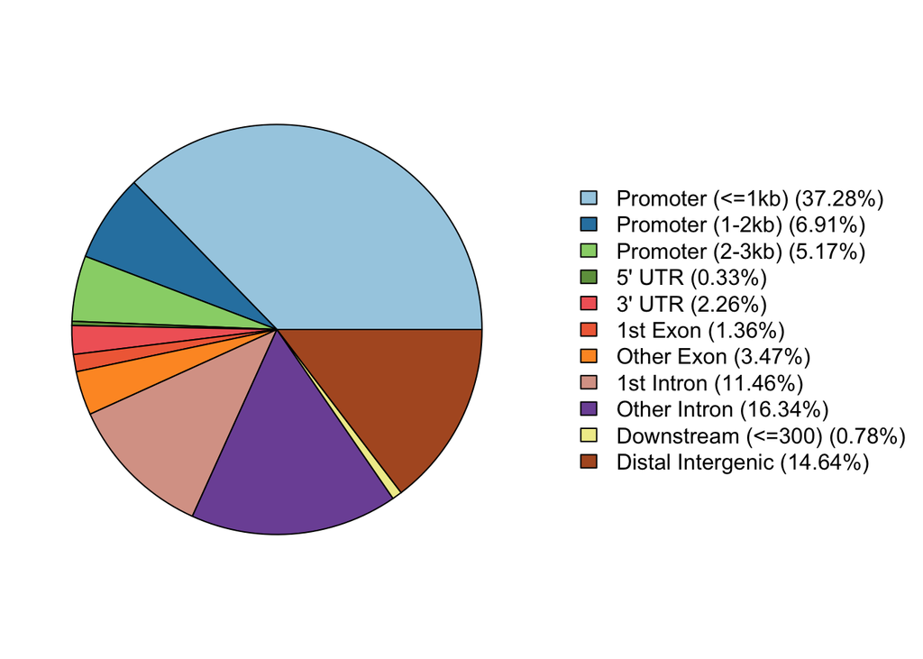

```r
plotAnnoPie(peakAnno)
```

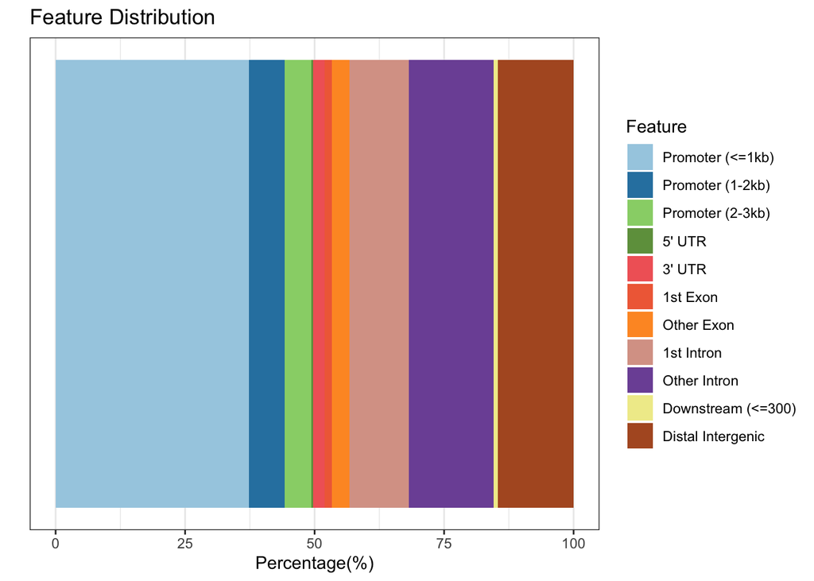

```r
plotAnnoBar(peakAnno)
```

## Pathway Analysis of Differentially Bound Genes

**NOTE:** As mentioned earlier, in this example, the positive vs negative fold change relationship is reversed, with Kpr associated genes assigned negative fold change. Pathways that go up or show enrichment are defined as fold < 0 and vise versa.

```r
# do pathway analysis in Reactome
#if (!requireNamespace("BiocManager", quietly = TRUE))
#    install.packages("BiocManager")
#BiocManager::install("ReactomePA")
library(ReactomePA)
head(diffprop$entrezID)
```

```
## [1] <NA>      57217     <NA>      113146    105371907 10801
## 12956 Levels: 1 100009676 10004 100048912 100049716 10005 10007 10008 ... 9993
```

Check number of features showing increased enrichment or association with Kpr.

```r
diffup <- diffprop[which(diffprop$fold < 0), ]
dim(diffup)
```

```
## [1] 43524    15
```

Check number of features showing decreased enrichment or association with Kac.

```r
diffdown <- diffprop[which(diffprop$fold > 0), ]
dim(diffdown)
```

```
## [1] 2119   15
```

Identify enriched pathways with p-adjusted value cutoff of 0.05.

```r
de <- (diffprop$entrezID)
length(de)
```

```
## [1] 45643
```

```r
de <- de[!is.na(de)]
head(de)
```

```
## [1] 57217     113146    105371907 10801     56945     165100
## 12956 Levels: 1 100009676 10004 100048912 100049716 10005 10007 10008 ... 9993
```

```r
length(de)
```

```
## [1] 32517
```

```r
x <- enrichPathway(gene=de,pvalueCutoff=0.05, readable=TRUE)
```

Make a dotplot showing pathways that go up or are associated with Kpr.

```r
deup <- diffup$entrezID
deup <- deup[!is.na(deup)]
length(deup)
```

```
## [1] 31214
```

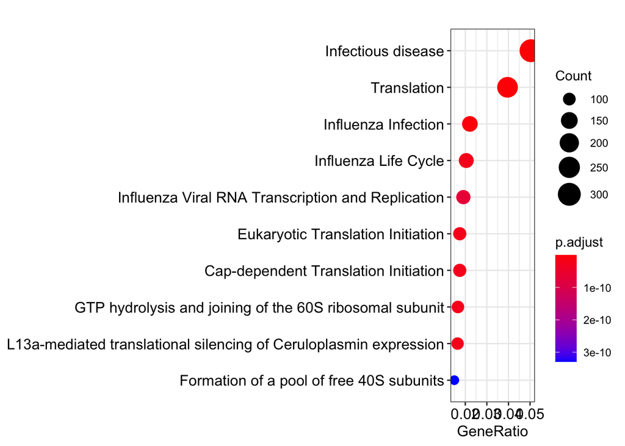

```r
xup <- enrichPathway(gene=deup,pvalueCutoff=0.05, readable=TRUE)
dotplot(xup, showCategory=10)
```